# D-Zeta relationship

The second set of params we are wroking with is

```r
guesses[[2]][1,] %>% select(-zeta, -d)
```

|  | model_type | R0 | gamma_val | omega_val | omega_m_val | kappa_val | rho_val | epsilon_val | mu_val | mj_val | m_val | delta_t | c | s | phi | c_v | s_v | phi_v | disp |
| --- | --- | --- | --- | --- | --- | --- | --- | --- | --- | --- | --- | --- | --- | --- | --- | --- | --- | --- | --- |
| 1 | 2 | 70.30774 | 11.65282 | 6.556869 | 0.801 | 5000 | 0 | 0 | 1.37 | 0.501 | 0.191 | 365 | 22.22618 | 146.7616 | 4.9036 | 1 | 136.5484 | 3.262018 | 171.146 |

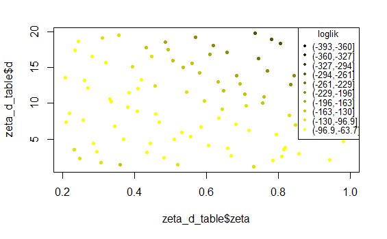

```r
model8_likelihoods %>% filter(abs(as.numeric(R0) - 70.30774 )<0.001) %>% select(zeta,d, loglik)  -> zeta_d_table
rbPal <- colorRampPalette(c('black','yellow'))
Col <- rbPal(10)[as.numeric(cut(zeta_d_table$loglik,breaks = 10))]

plot(zeta_d_table$zeta,zeta_d_table$d,pch = 20,col = Col)
 legend(
        "topright",
        inset=c(-0,0),
        title="loglik",
        legend=levels(cut(zeta_d_table$loglik,breaks = 10)),
        col =rbPal(10),
        pch=20,
        cex = 0.8,
        par(xpd=TRUE))
```

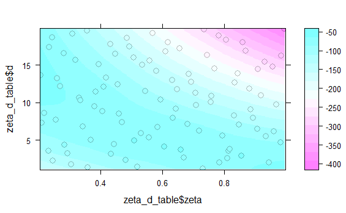

```r
levelplot(zeta_d_table$loglik ~ zeta_d_table$zeta*zeta_d_table$d,
          panel = panel.levelplot.points, cex = 1.2
    ) +
    layer_(panel.2dsmoother(..., n = 200))
```

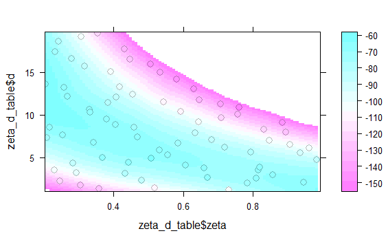

```r
 model8_likelihoods %>% filter(abs(as.numeric(R0) - 70.30774    )<0.001, loglik>max(loglik)-100) %>% select(zeta,d, loglik)  -> zeta_d_table
rbPal <- colorRampPalette(c('black','yellow'))
Col <- rbPal(10)[as.numeric(cut(zeta_d_table$loglik,breaks = 10))]

levelplot(zeta_d_table$loglik ~ zeta_d_table$zeta*zeta_d_table$d,
          panel = panel.levelplot.points, cex = 1.2
    ) +
    layer_(panel.2dsmoother(..., n = 100))
```

```r
  model8_likelihoods %>% filter(abs(as.numeric(R0) - 70.30774   )<0.001, loglik>max(loglik)-50) %>% select(zeta,d, loglik)  -> zeta_d_table
rbPal <- colorRampPalette(c('black','yellow'))
Col <- rbPal(10)[as.numeric(cut(zeta_d_table$loglik,breaks = 10))]

levelplot(zeta_d_table$loglik ~ zeta_d_table$zeta*zeta_d_table$d,
          panel = panel.levelplot.points, cex = 1.2, contour = TRUE,
          xlim =  c(0.2,0.9))+
    layer_(panel.2dsmoother(..., n = 100)) -> plt2
```

The third set of params we are wroking with is

```r
guesses[[3]][1,] %>% select(-zeta, -d)
```

|  | model_type | R0 | gamma_val | omega_val | omega_m_val | kappa_val | rho_val | epsilon_val | mu_val | mj_val | m_val | delta_t | c | s | phi | c_v | s_v | phi_v | disp |
| --- | --- | --- | --- | --- | --- | --- | --- | --- | --- | --- | --- | --- | --- | --- | --- | --- | --- | --- | --- |
| 1 | 2 | 51.73001 | 12.88068 | 15.51397 | 0.801 | 5000 | 0 | 0 | 1.37 | 0.501 | 0.191 | 365 | 32.74618 | 70.25272 | 8.142495 | 1 | 262.9244 | 3.2824 | 81.20734 |

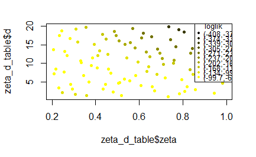

```r
model8_likelihoods %>% filter(abs(as.numeric(R0) - 51.73001 )<0.001) %>% select(zeta,d, loglik)  -> zeta_d_table
rbPal <- colorRampPalette(c('black','yellow'))
Col <- rbPal(10)[as.numeric(cut(zeta_d_table$loglik,breaks = 10))]

plot(zeta_d_table$zeta,zeta_d_table$d,pch = 20,col = Col)
 legend(
        "topright",
        inset=c(-0,0),
        title="loglik",
        legend=levels(cut(zeta_d_table$loglik,breaks = 10)),
        col =rbPal(10),
        pch=20,
        cex = 0.8,
        par(xpd=TRUE))
```

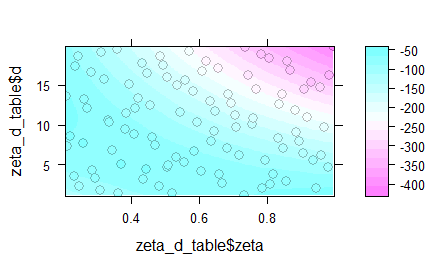

```r
levelplot(zeta_d_table$loglik ~ zeta_d_table$zeta*zeta_d_table$d,
          panel = panel.levelplot.points, cex = 1.2
    ) +
    layer_(panel.2dsmoother(..., n = 200))
```

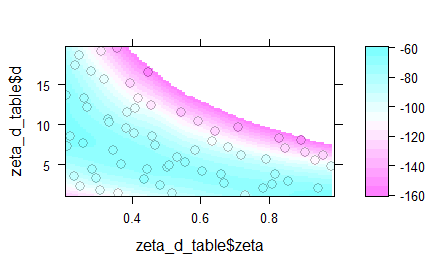

```r
 model8_likelihoods %>% filter(abs(as.numeric(R0) - 51.73001    )<0.001, loglik>max(loglik)-100) %>% select(zeta,d, loglik)  -> zeta_d_table
rbPal <- colorRampPalette(c('black','yellow'))
Col <- rbPal(10)[as.numeric(cut(zeta_d_table$loglik,breaks = 10))]

levelplot(zeta_d_table$loglik ~ zeta_d_table$zeta*zeta_d_table$d,
          panel = panel.levelplot.points, cex = 1.2
    ) +
    layer_(panel.2dsmoother(..., n = 100))
```

```r
  model8_likelihoods %>% filter(abs(as.numeric(R0) - 51.73001   )<0.001, loglik>max(loglik)-50) %>% select(zeta,d, loglik)  -> zeta_d_table
rbPal <- colorRampPalette(c('black','yellow'))
Col <- rbPal(10)[as.numeric(cut(zeta_d_table$loglik,breaks = 10))]

levelplot(zeta_d_table$loglik ~ zeta_d_table$zeta*zeta_d_table$d,
          panel = panel.levelplot.points, cex = 1.2, contour = TRUE,
          xlim =  c(0.2,0.9))+
    layer_(panel.2dsmoother(..., n = 100)) ->plt3
```

We would like to be able to only fit d or zeta, and find a function that allows us to calculate the other for the highest likelihood value. Let us try and see the contours of these areas for the three different cases.

```r
library(ggpubr)

plt1
plt2
plt3
```

[output not shown]

This suggests that there is a very strong correlation between zeta and d, the shape of the surface is almost the same, but they also depend on other variables as the location of the surfaces are different.